Authors: \ Rabin Adhikari \ 7072310 \ raad00002@stud.uni-saarland.de \

Dhimitrios Duka \ 7059153 \ dhdu00001@stud.uni-saarland.de \

# Assignment 3 - Generalization, Model Selection and Beyond Linearity

# Instructions

This assignment is worth a total of **10 points**. The goal of this assignment is to introduce you to selecting the best model using K fold cross validation. You will also explore methods for selecting hyperparameters to enhance the generalizability of your trained models.

We have structured the assignment into three parts:

1. **Part One**: Generalization
2. **Part Two**: Model Selection
3. **Part Three**: Beyond Linearity

To ensure you understand how each package is used, libraries will be imported as and when needed. The libraries used are all open source, and if you do not have any of these libraries installed, you can install them using the `pip install` method, either via your terminal or within a code cell in this notebook. For example, in your code cell you can use:

`!pip install matplotlib`

# Part One: Generalization, total of 3 points

We will make use of the "make classification" from sklearn datasets

```python
import warnings
warnings.filterwarnings('ignore')
```

### Make Classification Datasets and Plot

```python
import matplotlib.pyplot as plt
from sklearn.datasets import make_classification, make_circles
X, y = make_circles(n_samples=1000,factor=.25, noise=.30)
```

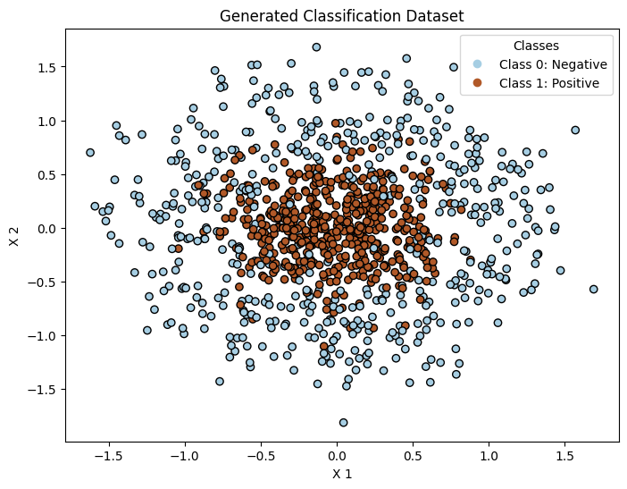

```python
def plot_dataset(X, y, title="Dataset"):
    """
    Plots the dataset with different colors for each class and adds a legend.

    Parameters:
    X (array-like): Feature matrix.
    y (array-like): Target vector.
    title (str): Title of the plot.
    """
    plt.figure(figsize=(8, 6))
    scatter = plt.scatter(X[:, 0], X[:, 1], c=y, edgecolors='k', cmap=plt.cm.Paired)
    plt.title(title)
    plt.xlabel("X 1")
    plt.ylabel("X 2")

    # Create a legend
    handles, labels = scatter.legend_elements()
    legend_labels = ['Class 0: Negative', 'Class 1: Positive']
    plt.legend(handles, legend_labels, title="Classes")

    plt.show()
plot_dataset(X, y, title="Generated Classification Dataset")
```

### Kfold Cross validation:

### Task 1: Implement a K-Fold cross-validation function as discussed in **Lecture 6** by filling in the parts of the code with TODOs.

The kfold cross-validation metric is calculated as:

$$ CV_k = \frac{1}{k} \sum_{i=1}^{k} \text{Metric}_i $$

The metrics we would use will be accuracy and the f1 score. We will use the inbuilt libraries for these metrics directly from sklearn.

#### Total: 1 point

```python
import numpy as np
from sklearn.metrics import accuracy_score, f1_score

def kfold_cross_validation(model, X, y, k=5, random_seed=0):
    """
    K-Fold cross-validation for a selected model.

    Parameters:
    model: The model you want to evaluate.
    X: The input features (numpy array or pandas DataFrame).
    y: The target variable (numpy array or pandas Series).
    k: Number of folds (default is 5).

    Returns:
    Average metrics across the K folds.
    """
    np.random.seed(random_seed)
    n_samples = len(X)
    # Get the fold size by dividing the number of samples by k
    fold_size =  n_samples // k  # TODO: Ensure integer division

    indices = np.arange(n_samples)
    np.random.shuffle(indices)  # Shuffle indices for random sampling

    # Initialize lists to store accuracies and f1_scores
    accuracies = [] # TODO: Accuracy list
    f1_scores = [] # TODO: F1 score list

    for i in range(k):
        # Select the test and train indices
        test_start_idx = i * fold_size
        test_end_idx = test_start_idx + fold_size
        test_indices =  indices[test_start_idx: test_end_idx] # TODO: Define test indices
        train_indices =  np.concatenate([indices[:test_start_idx], indices[test_end_idx:]]) # TODO: Define train indices

        X_train, X_test = X[train_indices], X[test_indices]
        y_train, y_test = y[train_indices], y[test_indices]

        # TODO: Model fitting on train
        # TODO: Use model to make Predictions on held out xtest

        model.fit(X_train, y_train)

        y_pred = model.predict(X_test)

        accuracy = accuracy_score(y_test, y_pred)  # TODO: Calculate accuracy and append to accuracies list
        accuracies.append(accuracy)

        f1 = f1_score(y_test, y_pred, average="weighted")   # TODO: Calculate weighted F1 score and append to f1_scores list
        f1_scores.append(f1)

    return np.mean(accuracies), np.mean(f1_scores) # TODO: Return average accuracy and F1 score
```

### Task 2: Fit 3 different models on your training data (i.e Logistic Regression, LDA, QDA) with your written 5-fold cross validation function above by filling in the parts of the code with TODO.

#### Total: 1 point

```python
from sklearn.linear_model import LogisticRegression
from sklearn.discriminant_analysis import LinearDiscriminantAnalysis, QuadraticDiscriminantAnalysis

# Instantiate your models
logistic_regression = LogisticRegression() #TODO
lda = LinearDiscriminantAnalysis() #TODO
qda =QuadraticDiscriminantAnalysis() #TODO

# Fit the models using k-fold cross-validation
lr_accuracy, lr_f1 = kfold_cross_validation(logistic_regression, X, y) #TODO
lda_accuracy, lda_f1 = kfold_cross_validation(lda, X, y) #TODO
qda_accuracy, qda_f1 = kfold_cross_validation(qda, X, y) #TODO


print(f'Logistic Regression: Accuracy = {lr_accuracy:.2f}, F1 Score = {lr_f1:.2f}')
print(f'LDA: Accuracy = {lda_accuracy:.2f}, F1 Score = {lda_f1:.2f}')
print(f'QDA: Accuracy = {qda_accuracy:.2f}, F1 Score = {qda_f1:.2f}')
```

```
Logistic Regression: Accuracy = 0.47, F1 Score = 0.41
LDA: Accuracy = 0.46, F1 Score = 0.41
QDA: Accuracy = 0.87, F1 Score = 0.87
```

### Evaluating Model Performance with Varying K

### Task 2.1: Write a for loop over different values of k by completing the sections of the code with TODO. Based on the output of your code, which model is the best and at which value of k?

#### Total: 0.5 points

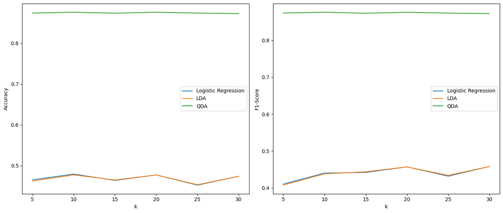

```python
# Define the range of k values
k_values = [5, 10, 15, 20, 25, 30]

# TODO:Initialize lists to store accuracy and f1 score of each model
lr_accuracies = []
lr_f1_scores = []
lda_accuracies = []
lda_f1_scores = []
qda_accuracies = []
qda_f1_scores = []

# Perform cross-validation for each value of k
for k in k_values:
    lr_accuracy, lr_f1 = kfold_cross_validation(logistic_regression, X, y, k) #TODO: Use written kfold_cross_validation  for the logistic regression model
    lda_accuracy, lda_f1 = kfold_cross_validation(lda, X, y, k) #TODO:  Use written kfold_cross_validation  for the lda model
    qda_accuracy, qda_f1 = kfold_cross_validation(qda, X, y, k) #TODO: Use written kfold_cross_validation  for the qda model

    lr_accuracies.append(lr_accuracy)
    lr_f1_scores.append(lr_f1)
    lda_accuracies.append(lda_accuracy)
    lda_f1_scores.append(lda_f1)
    qda_accuracies.append(qda_accuracy)
    qda_f1_scores.append(qda_f1)

# Plot the results
plt.figure(figsize=(14, 6))

# accuracy plot
plt.subplot(1, 2, 1)
# TODO: Plot the accuracy of each model
plt.plot(k_values, lr_accuracies, label="Logistic Regression")
plt.plot(k_values, lda_accuracies, label="LDA")
plt.plot(k_values, qda_accuracies, label="QDA")
plt.legend()
plt.ylabel("Accuracy")
plt.xlabel("k")


# F1 score plot
plt.subplot(1, 2, 2)
# TODO: Plot the F1 score of each model
plt.plot(k_values, lr_f1_scores, label="Logistic Regression")
plt.plot(k_values, lda_f1_scores, label="LDA")
plt.plot(k_values, qda_f1_scores, label="QDA")
plt.legend()
plt.ylabel("F1-Score")
plt.xlabel("k")

plt.tight_layout()
plt.show()
```

```python
for k, acc, f1 in zip(k_values, qda_accuracies, qda_f1_scores):
    print(k, acc, f1)
```

```
5 0.874 0.873984062045982
10 0.876 0.8760077850547082
15 0.8737373737373737 0.8733855493992202
20 0.876 0.8758406335058142
25 0.8740000000000001 0.8737110908956792
30 0.8727272727272729 0.8724082008689088
```

### Decision Boundary Calculation

### Task 3: Looking at the generated plots of the decision boundaries for the different models, can you write down what you observe

#### Total: 0.5 point for explanation

```python
def plot_decision_boundary(model, X, y, ax, title):
    x_min, x_max = X[:, 0].min() - 1, X[:, 0].max() + 1
    y_min, y_max = X[:, 1].min() - 1, X[:, 1].max() + 1
    xx, yy = np.meshgrid(np.arange(x_min, x_max, 0.01), np.arange(y_min, y_max, 0.01))
    Z = model.predict(np.c_[xx.ravel(), yy.ravel()])
    Z = Z.reshape(xx.shape)
    ax.contourf(xx, yy, Z, alpha=0.3)
    ax.scatter(X[:, 0], X[:, 1], c=y, edgecolors='k', marker='o')
    ax.set_title(title)
```

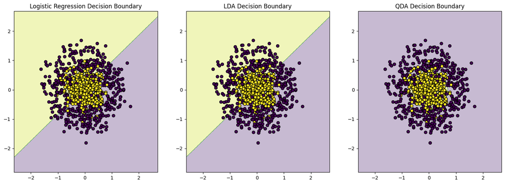

```python
fig, axes = plt.subplots(1, 3, figsize=(18, 6))
plot_decision_boundary(logistic_regression, X, y, axes[0], "Logistic Regression Decision Boundary")
plot_decision_boundary(lda, X, y, axes[1], "LDA Decision Boundary")
plot_decision_boundary(qda, X, y, axes[2], "QDA Decision Boundary")
plt.show()
```

**Answer:** From figure, we can see that logistic regression and LDA produce linear boundary, which is insufficient to separate the provided data. We can see the decision boundary of QDA to be a small ellipsoid (hard to see at first glance, but can be found from a nearer inspection). It models the circular boundary better, although some data points are still misclassified.

# Part Two: Model Selection, total of 3 points

In this section, we will:

- Fit Lasso and Ridge regression models.
- How to select the optimal $\lambda$ for each model.
- Compare the performance of the two models using the optimal $\lambda$ values.

```python
import matplotlib.pyplot as plt

def plot_regression_dataset(X, y, title="Regression Dataset"):
    """
    Plots the regression dataset with a color gradient representing the target values.
    Parameters:
    X (array-like): Feature matrix.
    y (array-like): Target vector.
    title (str): Title of the plot.
    """
    plt.figure(figsize=(8, 6))
    scatter = plt.scatter(X[:, 0], X[:, 1], c=y, cmap='viridis', edgecolors='k')
    plt.colorbar(label='Target Value')
    plt.title(title)
    plt.xlabel("X 1")
    plt.ylabel("X 2")

    plt.show()
```

### Datasets

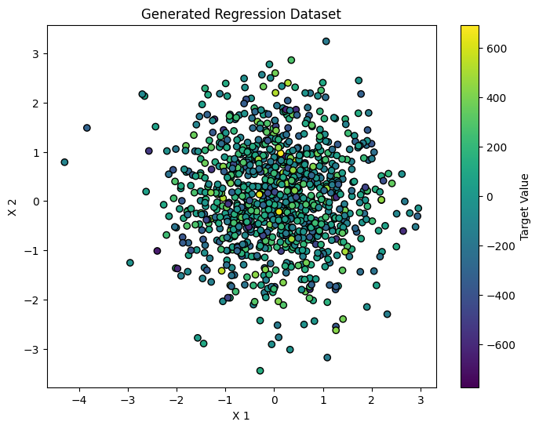

```python
from sklearn.datasets import make_regression

X_regression, y_regression = make_regression(n_samples=1000, n_features=50, n_informative=15, noise=0.35, random_state=42)
plot_regression_dataset(X_regression, y_regression, title="Generated Regression Dataset")
```

### Task 4: Fill in the missing parts of the code to fit ridge and lasso regression using different lambda values.

#### Total: 1 point

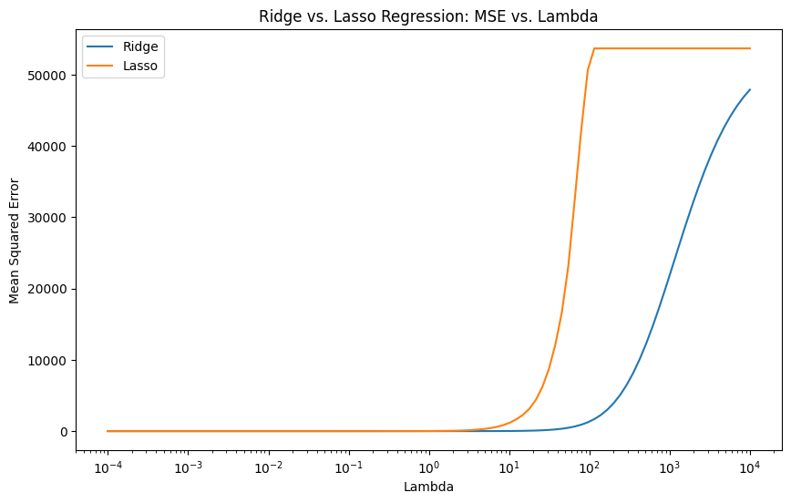

```
Optimal Lambda for Ridge Regression: 0.007
Optimal Lambda for Lasso Regression: 0.013
```

```python
import numpy as np
import matplotlib.pyplot as plt
from sklearn.linear_model import Ridge, Lasso
from sklearn.model_selection import train_test_split
from sklearn.model_selection import KFold, cross_val_score


X_train, X_test, y_train, y_test = train_test_split(X_regression, y_regression, test_size=0.3, random_state=42)

# Define a range of lambda values
lambda_values = np.logspace(-4, 4, 100)
mse_ridge = []
mse_lasso = []

# Define K-Fold cross-validation - NOTE we using the inbuilt KFold here
kf = KFold(n_splits=5, shuffle=True, random_state=42)

# Perform K-Fold Cross-Validation for Ridge Regression
for lambda_val in lambda_values:
    # TODO: Fit a Ridge regression model with the current lambda value
    mse_scores = cross_val_score(Ridge(lambda_val), X_train, y_train, scoring="neg_mean_squared_error", cv=kf, n_jobs=-1) # TODO: Use cross_val_score with 'neg_mean_squared_error'
    mse_ridge.append(-mse_scores.mean())  # Negate to get positive MSE

# Perform K-Fold Cross-Validation for Lasso Regression
for lambda_val in lambda_values:
    # TODO: Fit a Lasso regression model with the current lambda value
    mse_scores = cross_val_score(Lasso(lambda_val), X_train, y_train, scoring="neg_mean_squared_error", cv=kf, n_jobs=-1)# TODO: Use cross_val_score with 'neg_mean_squared_error'
    mse_lasso.append(-mse_scores.mean())  # Negate to get positive MSE

# Plot MSE vs. Lambda for Ridge and Lasso Regression
plt.figure(figsize=(10, 6))
# plt.figure(figsize=(10, 6))
# TODO: Plot the MSE for Ridge Regression (lambda values vs. mse_ridge)
plt.plot(lambda_values, mse_ridge, label="Ridge")
# TODO: Plot the MSE for Lasso Regression (lambda values vs. mse_lasso)
plt.plot(lambda_values, mse_lasso, label="Lasso")
plt.xscale('log')
plt.xlabel('Lambda')
plt.ylabel('Mean Squared Error')
plt.title('Ridge vs. Lasso Regression: MSE vs. Lambda')
plt.legend()
plt.show()

# Choose the optimal lambda for each model
optimal_lambda_ridge = lambda_values[np.argmin(mse_ridge)] # TODO: Select the best lambda value for Ridge
optimal_lambda_lasso = lambda_values[np.argmin(mse_lasso)] # TODO: Select the best lambda value for Lasso
print(f'Optimal Lambda for Ridge Regression: {optimal_lambda_ridge:.3f}')
print(f'Optimal Lambda for Lasso Regression: {optimal_lambda_lasso:.3f}')
```

### Task 5: Complete the code parts with TODOs and answer based on the output of your model, which model will you choose and why?

Using the optimal lambda values obtained from cross-validation for both Ridge and Lasso regression, follow these steps:

- Fit the Ridge and Lasso regression on your train data using the selected optimal lambda values.
- Evaluate the performance of the models on the testing set.
- Between the two models, which will you choose and why?

#### Total: 2 points

```python
from sklearn.metrics import mean_squared_error

# TODO: Fit Ridge Regression on train data with optimal lambda
ridge = Ridge(optimal_lambda_ridge).fit(X_train, y_train)
y_pred_ridge = ridge.predict(X_test)
mse_ridge = mean_squared_error(y_test, y_pred_ridge) #TODO: estimate the MSE

# TODO: Fit Lasso Regression train data with optimal lambda
lasso = Lasso(optimal_lambda_lasso).fit(X_train, y_train)
y_pred_lasso = lasso.predict(X_test)
mse_lasso = mean_squared_error(y_test, y_pred_lasso) #TODO: estimate the MSE

print(f"Lasso regression with lambda {optimal_lambda_lasso:.3f} has mse {mse_lasso:.3f} and ridge regression using lambda {optimal_lambda_ridge:.3f} has mse {mse_ridge:.3f}")
```

```
Lasso regression with lambda 0.013 has mse 0.117 and ridge regression using lambda 0.007 has mse 0.122
```

**Answer**: Here, lasso regression has lower mean squared error than that of ridge regression on the test set, so I would choose Lasso regression.

# Part Three: Beyond Linearity, total of 4 points

### Generate Datasets

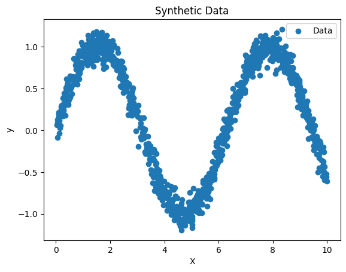

```python
import numpy as np
import matplotlib.pyplot as plt

np.random.seed(42)
num_samples = 1000
X_splines = np.sort(np.random.rand(num_samples) * 10)
y_splines = np.sin(X_splines) + np.random.randn(num_samples) * 0.1

# Plot the synthetic data
plt.scatter(X_splines, y_splines, label='Data')
plt.xlabel('X')
plt.ylabel('y')
plt.title('Synthetic Data')
plt.legend()
plt.show()
```

### Exploring Degrees Polynomial Regression

### Task 6: Fit polynomial regresion using different degrees. Complete all parts indicating TODOs. Based on your output, which degree would you select as best and why?

#### Total: 2 points

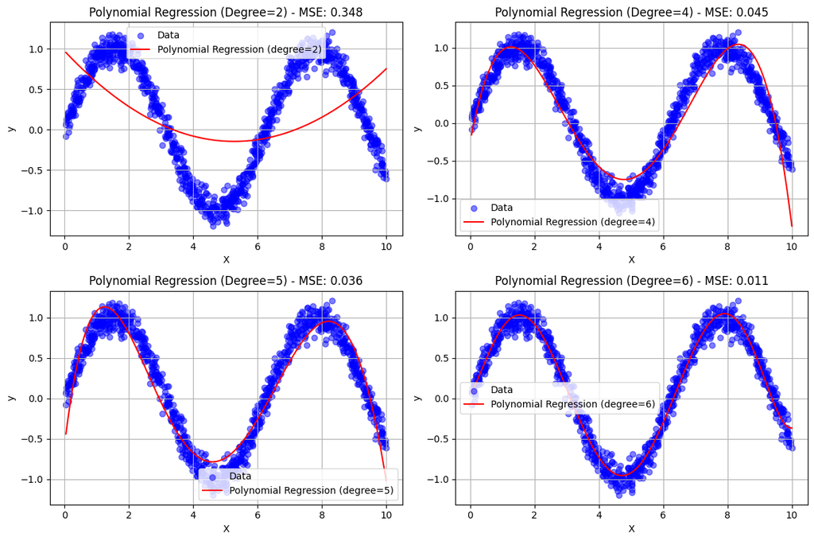

```python
import matplotlib.pyplot as plt
from sklearn.preprocessing import PolynomialFeatures
from sklearn.linear_model import LinearRegression

plt.figure(figsize=(12, 8))
degrees_range = [2, 4, 5, 6]

# Loop through different polynomial degrees
for j, degree in enumerate(degrees_range):
    # No need to include bias, since linear regression is adding it later on
    poly_features = PolynomialFeatures(degree, include_bias=False) # TODO: Create polynomial transformer
    X_poly = poly_features.fit_transform(X_splines.reshape(-1, 1))# TODO: Transform the features to polynomial features

    # TODO: Fit the polynomial regression model
    poly_model = LinearRegression().fit(X_poly, y_splines)

    # Predict the output
    y_poly_pred = poly_model.predict(X_poly)

    # Calculate the MSE for polynomial regression
    mse_poly = mean_squared_error(y_splines, y_poly_pred)

    # Plot the polynomial regression
    plt.subplot(2, 2, j + 1)  # 2 rows, 2 columns
    plt.scatter(X_splines, y_splines, label='Data', color='blue', alpha=0.5)
    plt.plot(X_splines, y_poly_pred, label=f'Polynomial Regression (degree={degree})', color='red')
    plt.xlabel('X')
    plt.ylabel('y')
    plt.title(f'Polynomial Regression (Degree={degree}) - MSE: {mse_poly:.3f}')
    plt.legend()
    plt.grid(True)

# Adjust layout
plt.tight_layout()
plt.show()
```

**Answer**: In this case, the polynomial regressions with degree less than six do not seem to change rapidly to fit the data well. Ans, when the degree of the fitted polynomial is six, it fits the data pretty closely. So I would choose the model with degree six here.

### Exploring Degrees and Knots on Spline Regression

### Task 7: Experiment with various degrees and knots. Here you will need to first complete the missing parts of the code. then answer the following questions based on your code output:

- What observations can you make regarding the effect of varying knots?
- Which specific combination of knots and degrees would you select?

#### Total: 2 points

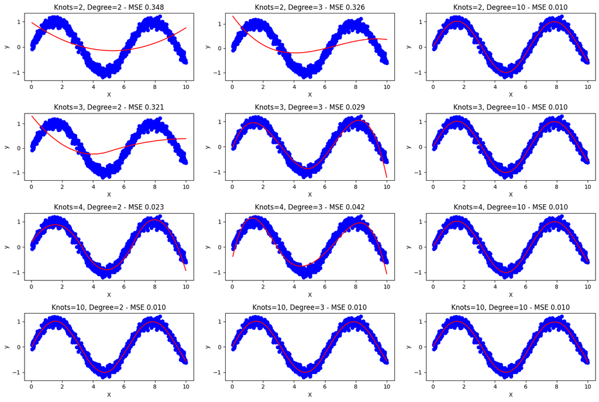

```python
from sklearn.preprocessing import SplineTransformer
from sklearn.pipeline import make_pipeline

plt.figure(figsize=(15, 10))
knots_range = [2, 3, 4, 10]
degrees_range = [2, 3, 10]
results = []
# Loop through different numbers of knots and degrees
for i, n_knots in enumerate(knots_range):
    for j, degree in enumerate(degrees_range):
        # No need to include bias, since linear regression is adding it later on
        spline_transformer =  SplineTransformer(n_knots=n_knots, degree=degree, include_bias=False) # TODO: Create a spline transformer
        spline_model = make_pipeline(spline_transformer, LinearRegression()) # TODO: Create linear regression pipeline

        # TODO: Fit the spline regression model
        spline_model.fit(X_splines.reshape(-1, 1), y_splines)

        y_spline_pred = spline_model.predict(X_splines.reshape(-1, 1))
        mse_spline = mean_squared_error(y_splines, y_spline_pred)

        # TODO:  Append knots, degree, and mse to results
        results.append((n_knots, degree, mse_spline))

        plt.subplot(len(knots_range), len(degrees_range), i * len(degrees_range) + (j + 1))
        plt.scatter(X_splines, y_splines, label='Data', color='blue')
        plt.plot(X_splines, y_spline_pred, label=f'Spline (knots={n_knots}, degree={degree})', color='red')

        plt.xlabel('X')
        plt.ylabel('y')
        plt.title(f'Knots={n_knots}, Degree={degree} - MSE {mse_spline:.3f}')

plt.tight_layout()
plt.show()
```

**Answer**: Increasing the number of knots increases the capability of model to capture local features. In the bottom left figure, only having degree 2 polynomial can fit the data perfectly when it has enough number of knots.

Here, I would pick the model with `knots=10, degree=2` (bottom left one) because of the following reasons.

1. It is one the models with the minimum MSE, so it fits the data perfectly.
2. The models having the same number of knots but higher degree do not reduce the MSE but are more complex (bottom row). Following Occam's razor, I choose the simplest option.
3. Another option would be to choose `knots=2, degree=10` using the same reasons as above. However, if the degree of polynomial is 10, then there is a high chance that I would behave drastically different at the boundaries (just a little bit further to the points we have data from).

# That is it for this assignment, we do hope you learn something from this exercise!